# Problem Set 1

Christen Parzych

8/20/2019

```r
## Clear environment
rm(list=ls())
## Get necessary libraries-- won't work the first time, because you need to install them!
library(tidyverse)
```

Please note that I included all work; Questions 3 and 4 were initially attempted prior to Week 2’s async. I felt that the original approaches were valuable learning experiences, and I elected to keep them for my own notes. Final answers are located last for each.

## 1. Write a sentence that says, “Hello, World!”

```r
## 1. A sentence that says, "Hello, World!"
print("Hello, World!")
```

```
## [1] "Hello, World!"
```

Please see above code to view my “Hello, World!” output.

## 2. Load R output that summarizes the variables in the college.Rdata dataset.

```r
## 2. R output that summarizes the variables in the college.Rdata dataset

library(tidyverse)

load("college.Rdata")

summary(sc)
```

```
##      unitid          instnm             stabbr               year
##  Min.   :106412   Length:125         Length:125         Min.   :2009
##  1st Qu.:140872   Class :character   Class :character   1st Qu.:2009
##  Median :190372   Mode  :character   Mode  :character   Median :2009
##  Mean   :185334                                         Mean   :2009
##  3rd Qu.:211440                                         3rd Qu.:2009
##  Max.   :446048                                         Max.   :2009
##
##     control         preddeg        adm_rate         sat_avg
##  Min.   :1.000   Min.   :1.00   Min.   :0.0000   Min.   : 759
##  1st Qu.:1.000   1st Qu.:3.00   1st Qu.:0.2350   1st Qu.:1031
##  Median :2.000   Median :3.00   Median :0.3237   Median :1263
##  Mean   :1.776   Mean   :2.96   Mean   :0.2901   Mean   :1200
##  3rd Qu.:2.000   3rd Qu.:3.00   3rd Qu.:0.3663   3rd Qu.:1389
##  Max.   :3.000   Max.   :3.00   Max.   :0.3992   Max.   :1514
##                                                  NA's   :27
##     costt4_a        debt_mdn     md_earn_wne_p6       ugds
##  Min.   : 8440   Min.   : 3750   Min.   :16100   Min.   :   27
##  1st Qu.:17671   1st Qu.: 8250   1st Qu.:28500   1st Qu.: 1753
##  Median :32865   Median :11562   Median :37650   Median : 3523
##  Mean   :33890   Mean   :11277   Mean   :39393   Mean   : 5745
##  3rd Qu.:50284   3rd Qu.:14500   3rd Qu.:48775   3rd Qu.: 6868
##  Max.   :53425   Max.   :18188   Max.   :81900   Max.   :30920
##  NA's   :1                       NA's   :3
```

I chose to use the ‘summary’ feature to display the summary output of the college file. I used the same explanations as in the async and added one additional for ‘udgd,’ based on my assumption of its meaning.

The dataset (“college.Rdata”) above includes the following variables:

*Variable Name* :*Definition* unitid: Unit ID

instnm: Institution Name

stabbr: State Abbreviation

year: Year

control: control of institution, 1=public, 2= private non-profit, 3=private for-profit

preddeg: predominant degree, 1= certificate, 2= associates, 3= bachelor’s, 4=graduate

adm_rate: Proportion of Applicants Admitted

sat_avg: Midpoint of entrance exam scores, on SAT scale, math and verbal only

costt_4a: Average cost of attendance (tuition and room and board less all grant aid)

debt_mdn: Median debt of graduates

md_earn_ne_pg: Earnings of graduates who are not enrolled in higher education, six years after graduation

New** ugds: number of undergrads (assumed)

## Question 1: Calculate the average earnings for individuals at the most selective colleges, then compare that with individuals at the least selective colleges in the dataset.

```r
##Calculate the average earnings for individuals at the most selective colleges, then compare that with individuals at the least selective colleges in the dataset.

library(tidyverse)
sc%>%filter(adm_rate<.1)%>%summarize(mean_earnings=mean(md_earn_wne_p6,na.rm=TRUE))
```

```
## # A tibble: 1 x 1
##   mean_earnings
##           <dbl>
## 1         53500
```

```r
sc%>%filter(adm_rate>.3)%>%summarize(mean_earnings=mean(md_earn_wne_p6,na.rm=TRUE))
```

```
## # A tibble: 1 x 1
##   mean_earnings
##           <dbl>
## 1        34747.
```

Average earnings for individuals at the most selective colleges is $53,500, while the average earnings for individuals at the least selective colleges is $34,747.14. I used admission rate and average earnings as variables to describe the selectivity of the institution and average earnings, respectively.

## Question 2: Find a way to determine whether colleges with very high SAT scores tend to be larger or smaller than colleges with low SAT scores.

```r
##Find a way to determine whether colleges with very high SAT scores tend to be larger or smaller than colleges with low SAT scores.

library(tidyverse)

sc%>%filter(sat_avg<900)%>%select(instnm,ugds)%>%
  arrange(-ugds)
```

```
## # A tibble: 11 x 2
##    instnm                                      ugds
##    <chr>                                      <int>
##  1 California State University-San Bernardino 14373
##  2 New Jersey City University                  6328
##  3 Grambling State University                  4534
##  4 Albany State University                     3988
##  5 University of Arkansas at Pine Bluff        3624
##  6 Delaware State University                   3222
##  7 Central State University                    2398
##  8 Mississippi Valley State University         2350
##  9 Kentucky State University                   2326
## 10 Lincoln University                          2020
## 11 Claflin University                          1735
```

```r
sc%>%filter(sat_avg>1400)%>%select(instnm,ugds)%>%
  arrange(-ugds)
```

```
## # A tibble: 20 x 2
##    instnm                                       ugds
##    <chr>                                       <int>
##  1 University of Pennsylvania                  10842
##  2 Northwestern University                      8905
##  3 University of Notre Dame                     8367
##  4 Columbia University in the City of New York  7743
##  5 Harvard University                           7181
##  6 Emory University                             6868
##  7 Vanderbilt University                        6764
##  8 Stanford University                          6564
##  9 Washington University in St Louis            6436
## 10 Duke University                              6416
## 11 Brown University                             6013
## 12 Yale University                              5258
## 13 Tufts University                             5146
## 14 University of Chicago                        5101
## 15 Princeton University                         5029
## 16 Massachusetts Institute of Technology        4218
## 17 Dartmouth College                            4090
## 18 Rice University                              3279
## 19 Williams College                             2033
## 20 California Institute of Technology            951
```

I chose to filter based on SAT scores and sorted the data based on the number of undergrads as a proxy for institution size (I added ‘udgd’ to the key). Based on the filters above, it appears colleges that require higher SAT scores tend to be larger than colleges with low SAT scores. California Institute of Technology has high SAT scores and a low undergrad population, but it is also a highly specialized school. Cal State San Bernadino has a large undergrad population and lower SAT scores, but it is a large state school.

## Question 3: Plot the relationship between cost and debt. What do you see? Does this surprise you?

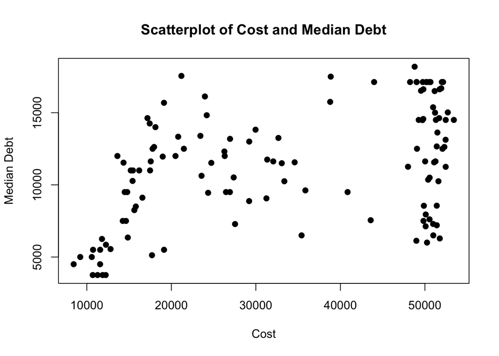

```r
##Plot the relationship between cost and debt. What do you see? Does this surprise you?

plot(sc$costt4_a, sc$debt_mdn,main="Scatterplot of Cost and Median Debt", xlab="Cost", ylab="Median Debt", pch=19)
```

I chose to use a scatterplot. The code was from our stats class. After viewing Week 2’s async, I decided to also try using the new ‘gg’ technique:

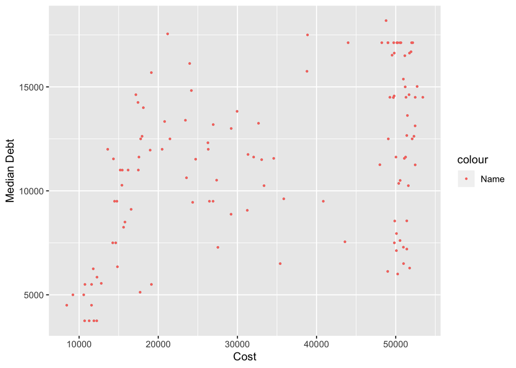

```r
library(plotly)
library(Metrics)


gg<-ggplot(data=sc, aes(y=debt_mdn,x=costt4_a,text=instnm))
gg<-gg+geom_point(alpha=.5,size=.5)
gg<-gg+geom_point(aes(y=debt_mdn,x=costt4_a,
                  color="Name"),
                  size=.5)
gg<-gg+xlab("Cost")+ylab("Median Debt")

gg
```

```r
gg4 <-gg
```

There seems to be a correlation between cost and debt (as cost increases, so too does debt) unti you get to the most expensive schools, where there is also data indicating that students who attend the most expensive schools don’t necessarily have the most debt. It does not surprise me; many expensive schools (like Vanderbilt) have higher endowments and more robust financial aid programs to offset the high cost. That being said, there are of course a large number of students who pay a high cost and incur high debt.

## Question 4: Provide separate plots for cost and debt by control of the institution.

```
## # A tibble: 125 x 12
##    unitid instnm stabbr  year control preddeg adm_rate sat_avg costt4_a
##     <int> <chr>  <chr>  <dbl>   <int>   <int>    <dbl>   <dbl>    <int>
##  1 446048 Ave M… FL      2009       2       3    0.374    1104    29200
##  2 443410 DigiP… WA      2009       3       3    0.326    1194    23969
##  3 111081 Calif… CA      2009       2       3    0.283      NA    48784
##  4 112260 Clare… CA      2009       2       3    0.163    1389    50990
##  5 113537 Dell'… CA      2009       2       1    0          NA       NA
##  6 404338 Schil… FL      2009       3       2    0.158      NA    35408
##  7 117928 Argos… CA      2009       3       3    0.323      NA    35858
##  8 120537 Hope … CA      2009       2       3    0.386     975    33366
##  9 119544 The N… CA      2009       3       3    0.261      NA    19135
## 10 107071 Hende… AR      2009       1       3    0.313    1048    14629
## # … with 115 more rows, and 3 more variables: debt_mdn <dbl>,
## #   md_earn_wne_p6 <int>, ugds <int>
```

[figure not shown]

```
## # A tibble: 125 x 12
##    unitid instnm stabbr  year control preddeg adm_rate sat_avg costt4_a
##     <int> <chr>  <chr>  <dbl>   <int>   <int>    <dbl>   <dbl>    <int>
##  1 446048 Ave M… FL      2009       2       3    0.374    1104    29200
##  2 443410 DigiP… WA      2009       3       3    0.326    1194    23969
##  3 111081 Calif… CA      2009       2       3    0.283      NA    48784
##  4 112260 Clare… CA      2009       2       3    0.163    1389    50990
##  5 113537 Dell'… CA      2009       2       1    0          NA       NA
##  6 404338 Schil… FL      2009       3       2    0.158      NA    35408
##  7 117928 Argos… CA      2009       3       3    0.323      NA    35858
##  8 120537 Hope … CA      2009       2       3    0.386     975    33366
##  9 119544 The N… CA      2009       3       3    0.261      NA    19135
## 10 107071 Hende… AR      2009       1       3    0.313    1048    14629
## # … with 115 more rows, and 3 more variables: debt_mdn <dbl>,
## #   md_earn_wne_p6 <int>, ugds <int>
```

[figure not shown]

That being said, I was reviewing this assignment with a colleague, and she mentioned she interpreted the above as three different plots showing cost/debt by institution, so I will also plot those (I am keeping my bar plots because I struggled to learn how to do them and want to keep it as notes for future reference):

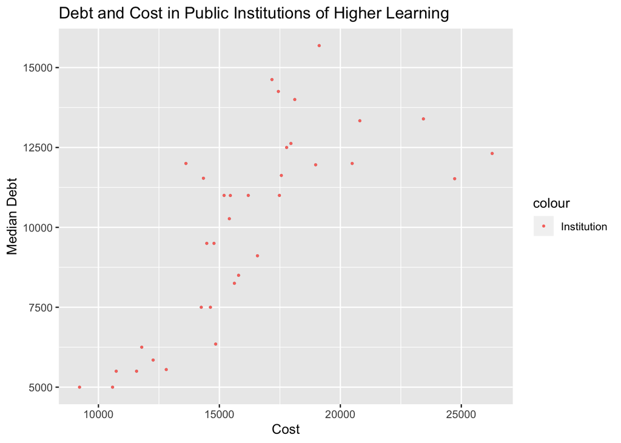

```r
Public <-sc%>%filter(control==1)%>%
  select(instnm,debt_mdn,costt4_a)%>%
  arrange(-debt_mdn)

library(plotly)
library(Metrics)
library(tidyverse)


gg<-ggplot(data=Public, aes(y=debt_mdn,x=costt4_a,text=instnm))
gg<-gg+geom_point(alpha=.5,size=.5)
gg<-gg+geom_point(aes(y=debt_mdn,x=costt4_a,
                  color="Institution"),
                  size=.5)
gg<-gg+xlab("Cost")+ylab("Median Debt")
gg<-gg+ggtitle("Debt and Cost in Public Institutions of Higher Learning")

gg
```

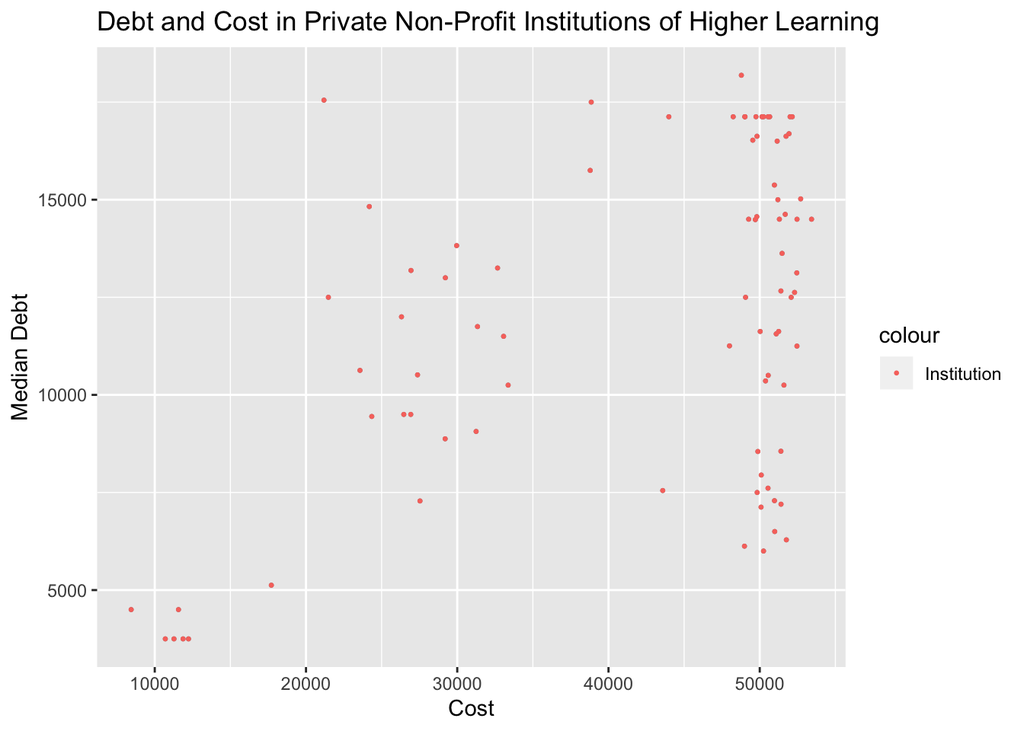

```r
gg5 <-gg

PrivateNP <-sc%>%filter(control==2)%>%
  select(instnm,debt_mdn,costt4_a)%>%
  arrange(-debt_mdn)

library(plotly)
library(Metrics)
library(tidyverse)


gg<-ggplot(data=PrivateNP, aes(y=debt_mdn,x=costt4_a,text=instnm))
gg<-gg+geom_point(alpha=.5,size=.5)
gg<-gg+geom_point(aes(y=debt_mdn,x=costt4_a,
                  color="Institution"),
                  size=.5)
gg<-gg+xlab("Cost")+ylab("Median Debt")
gg<-gg+ggtitle("Debt and Cost in Private Non-Profit Institutions of Higher Learning")

gg
```

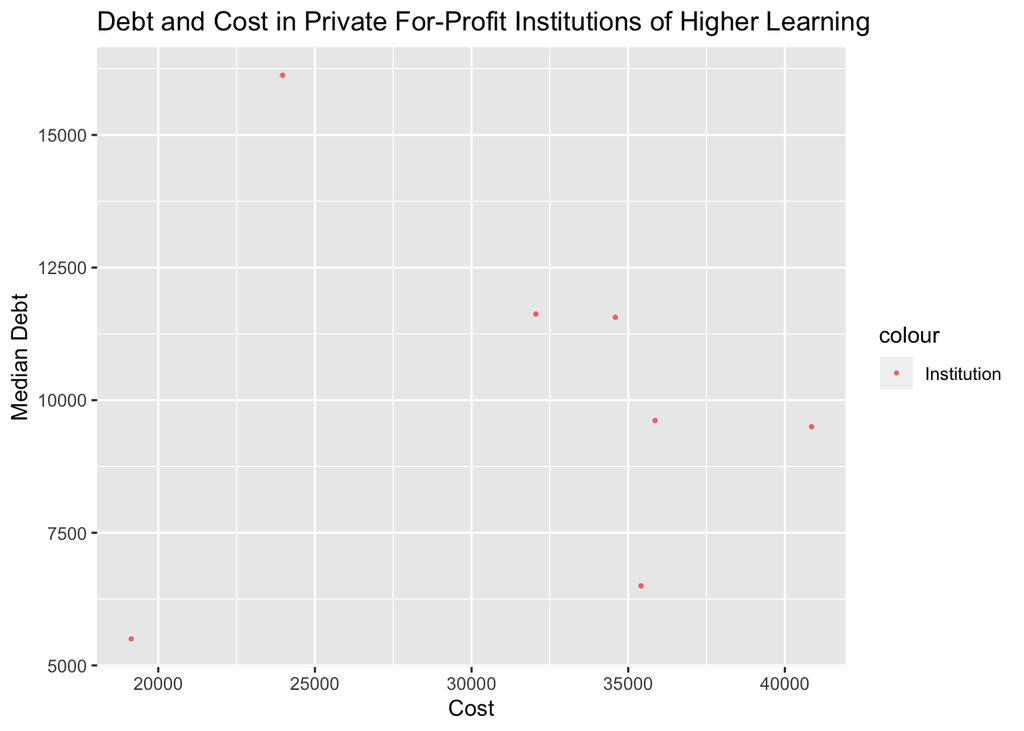

```r
gg6 <-gg

PrivateFP <-sc%>%filter(control==3)%>%
  select(instnm,debt_mdn,costt4_a)%>%
  arrange(-debt_mdn)

library(plotly)
library(Metrics)
library(tidyverse)


gg<-ggplot(data=PrivateFP, aes(y=debt_mdn,x=costt4_a,text=instnm))
gg<-gg+geom_point(alpha=.5,size=.5)
gg<-gg+geom_point(aes(y=debt_mdn,x=costt4_a,
                  color="Institution"),
                  size=.5)
gg<-gg+xlab("Cost")+ylab("Median Debt")
gg<-gg+ggtitle("Debt and Cost in Private For-Profit Institutions of Higher Learning")

gg
```

```r
gg6 <-gg
```

I am glad that I redid my plots. I chose to filter by control of the institution and selected on institution name, debt, and cost. I then renamed these objects and ran the gg plots on each of them.

The plot “Debt and Cost in Public Institutions of Higher Learning” indicates that as cost goes up, so too does median debt. The plot “Debt and Cost in Private Non-Profit Institutions of Higher Learning” aligns with what was found in the Q3 scatterplot. Debt and cost appear to be positively correlated until we get to those with the highest cost, in which case there is data showing low debt with high cost. There is not much data captured within “Debt and Cost in Private For-Profit Institutions of Higher Learning,” and I do not think we can interpret it.